# Project 1 Task 3

### Hrishikesh Deshpande (hd11) - Task 3.2

### Karthik Appana (kappana2) - Task 3.0

### Siddharth Gummadapu (sg96) - Task 3.1

```python
# imports
import numpy as np
import scipy.io as sio
import scipy.stats as stat
import matplotlib.pyplot as plt
```

### Patient 1

```python
# load data from mat file
pat1 = sio.loadmat('data_patients/patient1.mat')

pat1Floor = np.floor(pat1['all_data'])

pat1Cutoff = int(len(pat1['all_data'][0]) * (2/3))

pat1TrainData = []
for i in range(7):
    pat1TrainData.append(pat1Floor[i][:pat1Cutoff])
pat1TrainLabels = pat1['all_labels'][0][:pat1Cutoff]

pat1TestData = []
for i in range(7):
    pat1TestData.append(pat1Floor[i][pat1Cutoff:])
pat1TestLabels = pat1['all_labels'][0][pat1Cutoff:]
```

### Patient 2

```python
# load data from mat file
pat2 = sio.loadmat('data_patients/patient2.mat')

pat2Floor = np.floor(pat2['all_data'])

pat2Cutoff = int(len(pat2['all_data'][0]) * (2/3))

pat2TrainData = []
for i in range(7):
    pat2TrainData.append(pat2Floor[i][:pat2Cutoff])
pat2TrainLabels = pat2['all_labels'][0][:pat2Cutoff]

pat2TestData = []
for i in range(7):
    pat2TestData.append(pat2Floor[i][pat2Cutoff:])
pat2TestLabels = pat2['all_labels'][0][pat2Cutoff:]
```

### Patient 3

```python
# load data from mat file
pat3 = sio.loadmat('data_patients/patient3.mat')

pat3Floor = np.floor(pat3['all_data'])

pat3Cutoff = int(len(pat3['all_data'][0]) * (2/3))

pat3TrainData = []
for i in range(7):
    pat3TrainData.append(pat3Floor[i][:pat3Cutoff])
pat3TrainLabels = pat3['all_labels'][0][:pat3Cutoff]

pat3TestData = []
for i in range(7):
    pat3TestData.append(pat3Floor[i][pat3Cutoff:])
pat3TestLabels = pat3['all_labels'][0][pat3Cutoff:]
```

### Patient 4

```python
pat4 = sio.loadmat('data_patients/patient4.mat')

pat4Floor = np.floor(pat4['all_data'])

pat4Cutoff = int(len(pat4['all_data'][0]) * (2/3))

pat4TrainData = []
for i in range(7):
    pat4TrainData.append(pat4Floor[i][:pat4Cutoff])
pat4TrainLabels = pat4['all_labels'][0][:pat4Cutoff]

pat4TestData = []
for i in range(7):
    pat4TestData.append(pat4Floor[i][pat4Cutoff:])
pat4TestLabels = pat4['all_labels'][0][pat4Cutoff:]
```

### Patient 5

```python
pat5 = sio.loadmat('data_patients/patient5.mat')

pat5Floor = np.floor(pat5['all_data'])

pat5Cutoff = int(len(pat5['all_data'][0]) * (2/3))

pat5TrainData = []
for i in range(7):
    pat5TrainData.append(pat5Floor[i][:pat5Cutoff])
pat5TrainLabels = pat5['all_labels'][0][:pat5Cutoff]

pat5TestData = []
for i in range(7):
    pat5TestData.append(pat5Floor[i][pat5Cutoff:])
pat5TestLabels = pat5['all_labels'][0][pat5Cutoff:]
```

### Patient 6

```python
pat6 = sio.loadmat('data_patients/patient6.mat')

pat6Floor = np.floor(pat6['all_data'])

pat6Cutoff = int(len(pat6['all_data'][0]) * (2/3))

pat6TrainData = []
for i in range(7):
    pat6TrainData.append(pat6Floor[i][:pat6Cutoff])
pat6TrainLabels = pat6['all_labels'][0][:pat6Cutoff]

pat6TestData = []
for i in range(7):
    pat6TestData.append(pat6Floor[i][pat6Cutoff:])
pat6TestLabels = pat6['all_labels'][0][pat6Cutoff:]
```

### Patient 7

```python
pat7 = sio.loadmat('data_patients/patient7.mat')

pat7Floor = np.floor(pat7['all_data'])

pat7Cutoff = int(len(pat7['all_data'][0]) * (2/3))

pat7TrainData = []
for i in range(7):
    pat7TrainData.append(pat7Floor[i][:pat7Cutoff])
pat7TrainLabels = pat7['all_labels'][0][:pat7Cutoff]

pat7TestData = []
for i in range(7):
    pat7TestData.append(pat7Floor[i][pat7Cutoff:])
pat7TestLabels = pat7['all_labels'][0][pat7Cutoff:]
```

### Patient 8

```python
pat8 = sio.loadmat('data_patients/patient8.mat')

pat8Floor = np.floor(pat8['all_data'])

pat8Cutoff = int(len(pat8['all_data'][0]) * (2/3))

pat8TrainData = []
for i in range(7):
    pat8TrainData.append(pat8Floor[i][:pat8Cutoff])
pat8TrainLabels = pat8['all_labels'][0][:pat8Cutoff]

pat8TestData = []
for i in range(7):
    pat8TestData.append(pat8Floor[i][pat8Cutoff:])
pat8TestLabels = pat8['all_labels'][0][pat8Cutoff:]
```

### Patient 9

```python
pat9 = sio.loadmat('data_patients/patient9.mat')

pat9Floor = np.floor(pat9['all_data'])

pat9Cutoff = int(len(pat9['all_data'][0]) * (2/3))

pat9TrainData = []
for i in range(7):
    pat9TrainData.append(pat9Floor[i][:pat9Cutoff])
pat9TrainLabels = pat9['all_labels'][0][:pat9Cutoff]

pat9TestData = []
for i in range(7):
    pat9TestData.append(pat9Floor[i][pat9Cutoff:])
pat9TestLabels = pat9['all_labels'][0][pat9Cutoff:]
```

### Task 3.1a - Prior Probabilities

```python
def getPriorVals(trainLabels):
    priorH0 = list(trainLabels).count(0) / len(trainLabels)
    priorH1 = list(trainLabels).count(1) / len(trainLabels)

    return round(priorH0, 2), round(priorH1, 2)
```

```python
pat1PriorH0, pat1PriorH1 = getPriorVals(pat1TrainLabels)
pat2PriorH0, pat2PriorH1 = getPriorVals(pat2TrainLabels)
pat3PriorH0, pat3PriorH1 = getPriorVals(pat3TrainLabels)
pat4PriorH0, pat4PriorH1 = getPriorVals(pat4TrainLabels)
pat5PriorH0, pat5PriorH1 = getPriorVals(pat5TrainLabels)
pat6PriorH0, pat6PriorH1 = getPriorVals(pat6TrainLabels)
pat7PriorH0, pat7PriorH1 = getPriorVals(pat7TrainLabels)
pat8PriorH0, pat8PriorH1 = getPriorVals(pat8TrainLabels)
pat9PriorH0, pat9PriorH1 = getPriorVals(pat9TrainLabels)
```

### Task 3.1b - Calculating Likelihood Matrices

```python
def likelihoodMatrix(trainData, trainLabels):
    likelihoodMatrices = []

    for featureIdx in range(7):
        featureData = trainData[featureIdx]
        labels = trainLabels

        minVal = int(np.min(featureData))
        maxVal = int(np.max(featureData))
        possibleValues = range(minVal, maxVal + 1)

        countMatrix = np.zeros((2, len(possibleValues)))

        for i in range(len(featureData)):
            classIdx = int(labels[i])
            valueIdx = int(featureData[i]) - minVal
            countMatrix[classIdx][valueIdx] += 1

        h0Total = np.sum(countMatrix[0])
        h1Total = np.sum(countMatrix[1])

        likelihoodMatrix = np.zeros((2, len(possibleValues)))

        for valIdx in range(len(possibleValues)):
            likelihoodMatrix[0][valIdx] = countMatrix[0][valIdx] / h0Total if h0Total > 0 else 0
            likelihoodMatrix[1][valIdx] = countMatrix[1][valIdx] / h1Total if h1Total > 0 else 0

        likelihoodMatrices.append(likelihoodMatrix)

    return likelihoodMatrices
```

```python
pat1LM = likelihoodMatrix(pat1TrainData, pat1TrainLabels)
pat2LM = likelihoodMatrix(pat2TrainData, pat2TrainLabels)
pat3LM = likelihoodMatrix(pat3TrainData, pat3TrainLabels)
pat4LM = likelihoodMatrix(pat4TrainData, pat4TrainLabels)
pat5LM = likelihoodMatrix(pat5TrainData, pat5TrainLabels)
pat6LM = likelihoodMatrix(pat6TrainData, pat6TrainLabels)
pat7LM = likelihoodMatrix(pat7TrainData, pat7TrainLabels)
pat8LM = likelihoodMatrix(pat8TrainData, pat8TrainLabels)
pat9LM = likelihoodMatrix(pat9TrainData, pat9TrainLabels)
```

### Task 3.1c - Patient Graphs

```python
def plotData(trainData, likelihoodMatrices, patientName):

   fig, axes = plt.subplots(2, 4, figsize=(16, 6))
   fig.suptitle(f"Conditional PMFs for {patientName}", fontsize=16)

   axes = axes.flatten()

   for featureIdx in range(7):
       likelihoodMatrix = likelihoodMatrices[featureIdx]

       numValues = likelihoodMatrix.shape[1]

       minVal = int(np.min(trainData[featureIdx]))
       xValues = range(minVal, minVal + numValues)

       axes[featureIdx].bar(xValues, likelihoodMatrix[0], alpha=0.5, label='H0', color='blue')

       axes[featureIdx].bar(xValues, likelihoodMatrix[1], alpha=0.5, label='H1', color='red')

       axes[featureIdx].set_title(f"Feature {featureIdx+1}")
       axes[featureIdx].set_xlabel("Feature Value")
       axes[featureIdx].set_ylabel("Probability P(x|H)")
       axes[featureIdx].legend()

   if len(axes) > 7:
       axes[7].axis('off')

   plt.tight_layout()
   plt.subplots_adjust(top=0.9)
```

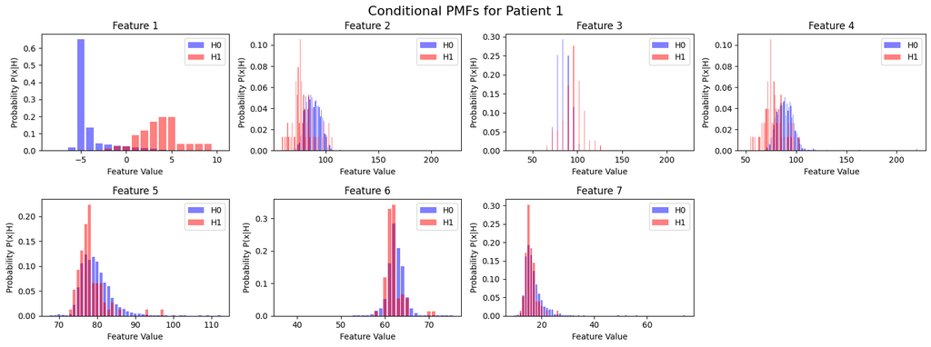

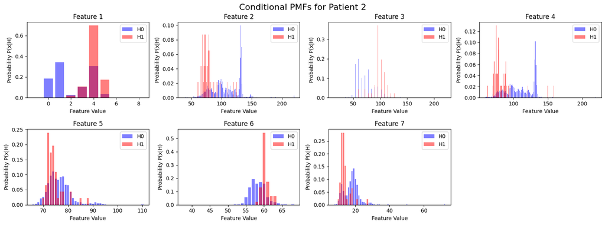

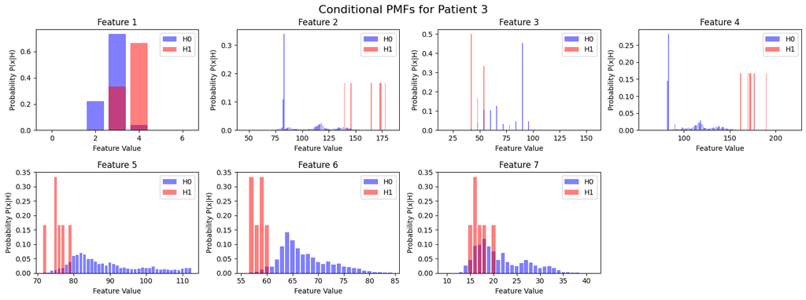

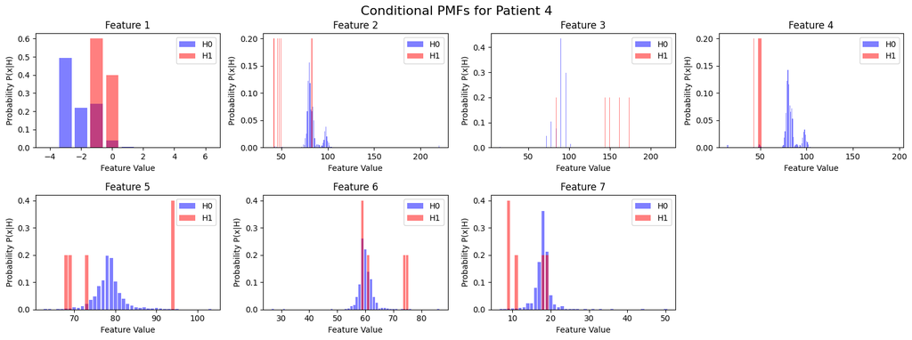

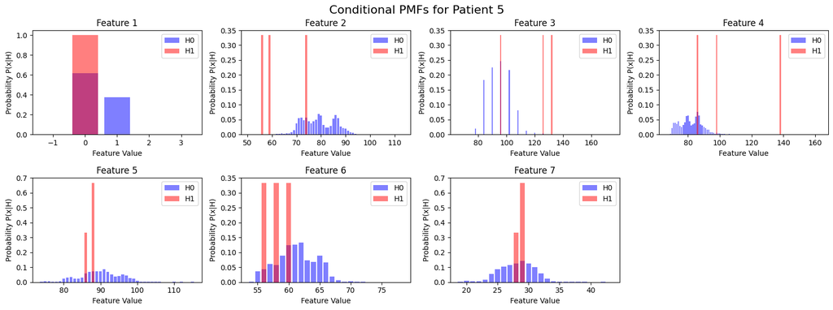

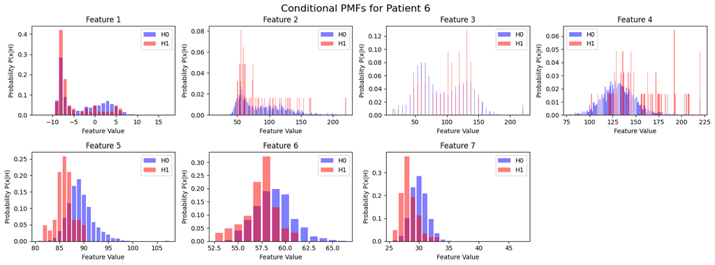

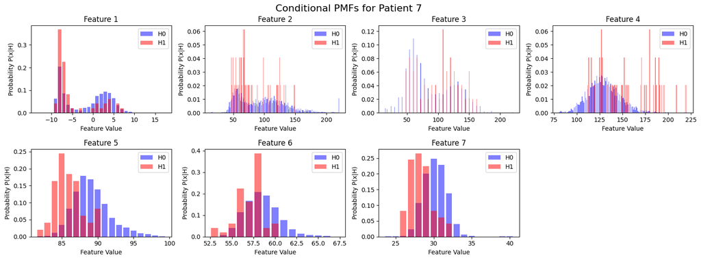

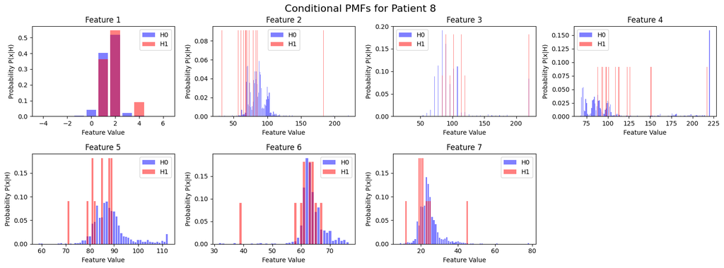

[figure not shown]

```python
plotData(pat1TrainData, pat1LM, "Patient 1")
plotData(pat2TrainData, pat2LM, "Patient 2")
plotData(pat3TrainData, pat3LM, "Patient 3")
plotData(pat4TrainData, pat4LM, "Patient 4")
plotData(pat5TrainData, pat5LM, "Patient 5")
plotData(pat6TrainData, pat6LM, "Patient 6")
plotData(pat7TrainData, pat7LM, "Patient 7")
plotData(pat8TrainData, pat8LM, "Patient 8")
plotData(pat9TrainData, pat9LM, "Patient 9")
```

### Task 3.1d - ML and MAP Decision Vectors

```python
def mlRule(likelihoodMatrices):
    MLArr = []
    for feature in likelihoodMatrices:
        featureMLArr = []
        for i in range(len(feature[0])):
            if feature[1][i] >= feature[0][i]:
                featureMLArr.append(1)
            else:
                featureMLArr.append(0)
        MLArr.append(featureMLArr)

    return MLArr


def mapRule(likelihoodMatrices, priorH0, priorH1):
    MAPArr = []
    for feature in likelihoodMatrices:
        featureMAPArr = []
        for i in range(len(feature[0])):
            if (priorH1 * feature[1][i]) >= (priorH0 * feature[0][i]):
                featureMAPArr.append(1)
            else:
                featureMAPArr.append(0)
        MAPArr.append(featureMAPArr)

    return MAPArr
```

### Task 3.1e - Hypotheses Table

```python
def hypTable(likelihoodMatrices, trainData, priorH0, priorH1):

    mainTable = []
    for featIdx in range(7):
        table = []
        featureData = trainData[featIdx]
        minVal = int(np.min(featureData))
        maxVal = int(np.max(featureData))
        possibleValues = range(minVal, maxVal + 1)
        table.append([i for i in possibleValues])
        table.append(likelihoodMatrices[featIdx][0])
        table.append(likelihoodMatrices[featIdx][1])
        mlArr = mlRule(likelihoodMatrices)
        table.append(mlArr[featIdx])
        mapArr = mapRule(likelihoodMatrices, priorH0, priorH1)
        table.append(mapArr[featIdx])
        npTable = np.array(table)
        mainTable.append(npTable.T)

    return mainTable
```

```python
pat1Table = hypTable(pat1LM, pat1TrainData, pat1PriorH0, pat1PriorH1)
pat2Table = hypTable(pat2LM, pat2TrainData, pat2PriorH0, pat2PriorH1)
pat3Table = hypTable(pat3LM, pat3TrainData, pat3PriorH0, pat3PriorH1)
pat4Table = hypTable(pat4LM, pat4TrainData, pat4PriorH0, pat4PriorH1)
pat5Table = hypTable(pat5LM, pat5TrainData, pat5PriorH0, pat5PriorH1)
pat6Table = hypTable(pat6LM, pat6TrainData, pat6PriorH0, pat6PriorH1)
pat7Table = hypTable(pat7LM, pat7TrainData, pat7PriorH0, pat7PriorH1)
pat8Table = hypTable(pat8LM, pat8TrainData, pat8PriorH0, pat8PriorH1)
pat9Table = hypTable(pat9LM, pat9TrainData, pat9PriorH0, pat9PriorH1)

finalHypothesisTable = [pat1Table, pat2Table, pat3Table, pat4Table,
                        pat5Table, pat6Table, pat7Table, pat8Table, pat9Table]
```

### Task 3.2a - Alarm Predictions

```python
def generatePreds(testData, hypeTable):
    allMLPreds = []
    allMAPPreds = []

    for i in range(7):
        mlPreds = []
        mapPreds = []

        featureValues = [arr[0] for arr in hypeTable[i]]

        for elem in testData[i]:
            foundMatch = False
            for arr in hypeTable[i]:
                if elem == arr[0]:
                    mlPreds.append(arr[3])
                    mapPreds.append(arr[4])
                    foundMatch = True
                    break

            if not foundMatch:
                closestIdx = np.argmin(np.abs(np.array(featureValues) - elem))
                mlPreds.append(hypeTable[i][closestIdx][3])
                mapPreds.append(hypeTable[i][closestIdx][4])

        allMLPreds.append(mlPreds)
        allMAPPreds.append(mapPreds)

    return allMLPreds, allMAPPreds
```

```python
pat1MLPreds, pat1MAPPreds = generatePreds(pat1TestData, pat1Table)
pat2MLPreds, pat2MAPPreds = generatePreds(pat2TestData, pat2Table)
pat3MLPreds, pat3MAPPreds = generatePreds(pat3TestData, pat3Table)
pat4MLPreds, pat4MAPPreds = generatePreds(pat4TestData, pat4Table)
pat5MLPreds, pat5MAPPreds = generatePreds(pat5TestData, pat5Table)
pat6MLPreds, pat6MAPPreds = generatePreds(pat6TestData, pat6Table)
pat7MLPreds, pat7MAPPreds = generatePreds(pat7TestData, pat7Table)
pat8MLPreds, pat8MAPPreds = generatePreds(pat8TestData, pat8Table)
pat9MLPreds, pat9MAPPreds = generatePreds(pat9TestData, pat9Table)
```

### Task 3.2b - Error Probabilities

```python
def errorTable(predsML, predsMAP, testLabels):
    errorArr = []
    for i in range(7):
        falseAlarmsML = 0
        missDetectionsML = 0

        falseAlarmsMAP = 0
        missDetectionsMAP = 0

        for j in range(len(predsML[i])):
            if predsML[i][j] == 0 and testLabels[j] == 1:
                missDetectionsML += 1
            if predsML[i][j] == 1 and testLabels[j] == 0:
                falseAlarmsML += 1

        for j in range(len(predsMAP[i])):
            if predsMAP[i][j] == 0 and testLabels[j] == 1:
                missDetectionsMAP += 1
            if predsMAP[i][j] == 1 and testLabels[j] == 0:
                falseAlarmsMAP += 1


        falseAlarmsML /= len(predsML[i])
        falseAlarmsMAP /= len(predsMAP[i])

        missDetectionsML /= len(predsML[i])
        missDetectionsMAP /= len(predsMAP[i])


        errorML = 0.5 * falseAlarmsML + 0.5 * missDetectionsML
        errorMAP = pat1PriorH0 * falseAlarmsMAP + pat1PriorH1 * missDetectionsMAP

        errorArr.append([[falseAlarmsML, missDetectionsML, errorML], [falseAlarmsMAP, missDetectionsMAP, errorMAP]])

    return errorArr
```

```python
pat1ErrorTable = errorTable(pat1MLPreds, pat1MAPPreds, pat1TestLabels)
pat2ErrorTable = errorTable(pat2MLPreds, pat2MAPPreds, pat2TestLabels)
pat3ErrorTable = errorTable(pat3MLPreds, pat3MAPPreds, pat3TestLabels)
pat4ErrorTable = errorTable(pat4MLPreds, pat4MAPPreds, pat4TestLabels)
pat5ErrorTable = errorTable(pat5MLPreds, pat5MAPPreds, pat5TestLabels)
pat6ErrorTable = errorTable(pat6MLPreds, pat6MAPPreds, pat6TestLabels)
pat7ErrorTable = errorTable(pat7MLPreds, pat7MAPPreds, pat7TestLabels)
pat8ErrorTable = errorTable(pat8MLPreds, pat8MAPPreds, pat8TestLabels)
pat9ErrorTable = errorTable(pat9MLPreds, pat9MAPPreds, pat9TestLabels)

finalErrorTable = [pat1ErrorTable, pat2ErrorTable, pat3ErrorTable, pat4ErrorTable,
                   pat5ErrorTable, pat6ErrorTable, pat7ErrorTable, pat8ErrorTable, pat9ErrorTable]
```

## Task 3.2 - Feature Pair Selection

### Lowest Error Pairs Test

```python
bestMLPairsArr = []
bestMAPPairsArr = []

for errTable in finalErrorTable:
    mlErrs = []
    mapErrs = []
    for errorArr in errTable:
        mlErrs.append(errorArr[0][2])
        mapErrs.append(errorArr[1][2])

    # print(mlErrs)
    # print(mapErrs)
    bestFeatPairML = np.argsort(mlErrs)[:2] + 1
    bestFeatPairMAP = np.argsort(mapErrs)[:2] + 1
    bestMLPairsArr.append(bestFeatPairML)
    bestMAPPairsArr.append(bestFeatPairMAP)

print("Best ML Rule Feature Pairs for each Patient: ", bestMLPairsArr)
print("Best MAP Rule Feature Pairs for each Patient: ", bestMAPPairsArr)
```

```
Best ML Rule Feature Pairs for each Patient:  [array([1, 3]), array([6, 4]), array([1, 5]), array([7, 5]), array([4, 1]), array([4, 6]), array([5, 6]), array([2, 3]), array([4, 6])]
Best MAP Rule Feature Pairs for each Patient:  [array([6, 3]), array([1, 5]), array([1, 5]), array([1, 7]), array([1, 7]), array([3, 6]), array([3, 5]), array([1, 3]), array([3, 6])]
```

### Golden Alarm Correlation Test

```python
def analyzeFeatureAlarmCorrelation(patientTestData, patientTestLabels, patientName):
    correlations = []

    plt.figure(figsize=(15, 10))
    plt.suptitle(f'Feature vs Golden Alarms Correlation for {patientName}', fontsize=16)

    for featureIdx in range(7):
        featureData = patientTestData[featureIdx]
        correlation = np.corrcoef(featureData, patientTestLabels)[0, 1]
        correlations.append(correlation)

    plt.figure(figsize=(10, 6))
    plt.bar(range(1, 8), np.abs(correlations))
    plt.xlabel('Feature')
    plt.ylabel('|Correlation with Golden Alarms|')
    plt.title(f'Feature-Alarm Correlation Magnitudes for {patientName}')
    plt.xticks(range(1, 8))
    plt.ylim(0, 1)

    return correlations
```

```
Patient 1 - Top 2 correlated features: [1 3] with correlations: [0.5287154422038963, 0.30151677386561837]
Patient 3 - Top 2 correlated features: [1 7] with correlations: [-0.05205556044446076, 0.03486218797046112]
Patient 4 - Top 2 correlated features: [2 5] with correlations: [0.10028935858094924, -0.09950230996429597]
Patient 5 - Top 2 correlated features: [3 4] with correlations: [0.16341836819567962, 0.14606344739898264]
Patient 6 - Top 2 correlated features: [4 6] with correlations: [0.1957787974996459, -0.1585817167459278]
```

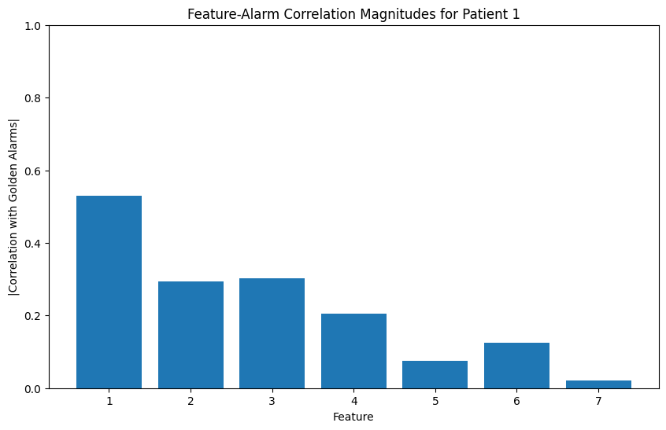

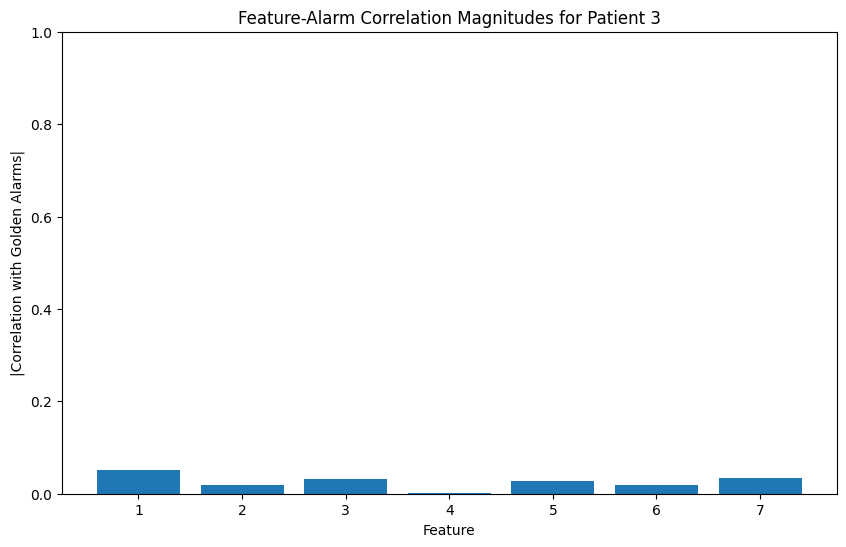

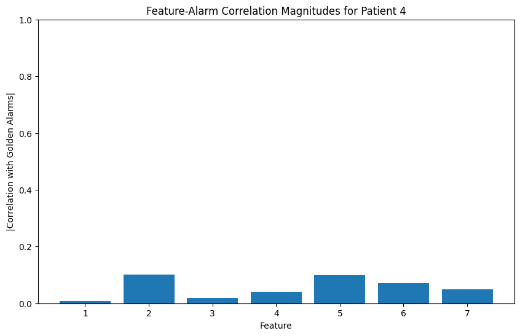

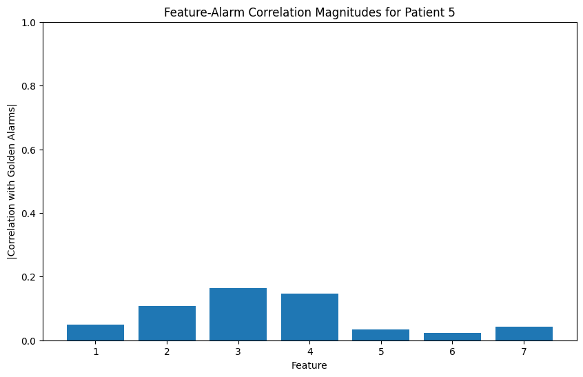

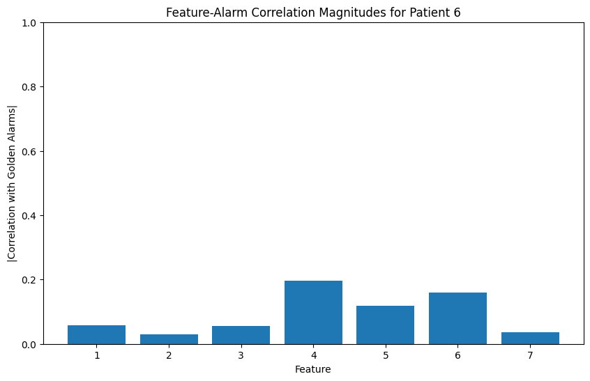

```python
pat1Correlations = analyzeFeatureAlarmCorrelation(pat1TestData, pat1TestLabels, "Patient 1")
pat3Correlations = analyzeFeatureAlarmCorrelation(pat3TestData, pat3TestLabels, "Patient 3")
pat4Correlations = analyzeFeatureAlarmCorrelation(pat4TestData, pat4TestLabels, "Patient 4")
pat5Correlations = analyzeFeatureAlarmCorrelation(pat5TestData, pat5TestLabels, "Patient 5")
pat6Correlations = analyzeFeatureAlarmCorrelation(pat6TestData, pat6TestLabels, "Patient 6")

for patientNum, correlations in [(1, pat1Correlations), (3, pat3Correlations),
                                 (4, pat4Correlations), (5, pat5Correlations), (6, pat6Correlations)]:
    absCorrelations = np.abs(correlations)
    topFeatures = np.argsort(absCorrelations)[-2:][::-1]
    print(f"Patient {patientNum} - Top 2 correlated features:
          {topFeatures + 1} with correlations: {[correlations[i] for i in topFeatures]}")
```

## Pair Decisions Based on Data

### ML Rule: Patients 1, 3, 4

Patient 1 - Features 1 and 3:

In both the lowest error test and the golden alarm correlation test, both features 1 and 3 seemed to be the most accurate and prominent in determining the result for Patient 1.

Patient 3 - Features 1 and 7:

In both the lowest error test and the golden alarm correlation test, feature 1 seemed to be the most accurate and prominent in determining the result for Patient 3. The next step was to choose between lower error (feature 5) or higher impact (feature 7). In this case we decided to go with feature 7 as our second option because it also had a decently low error while providing a more significant impact on the patient's results.

### MAP Rule: Patients 3, 5, 6

Patient 3 - Features 1 and 7:

In both the lowest error test and the golden alarm correlation test, feature 1 seemed to be the most accurate and prominent in determining the result for Patient 3. The next step was to choose between lower error (feature 5) or higher impact (feature 7). In this case we decided to go with feature 7 as our second option because it also had a decently low error while providing a more significant impact on the patient's results.

Patient 5 - Features 3 and 1:

For this patient, we got completely different pairs in both the lowest error test and the golden alarm correlation test. So we decided to choose the best of the 2 pairs and combine them into the pair of features for this patient. From the lower error test, we chose feature 1 since it had the lowest error, and from the golden alarm correlation test we chose feature 3 since it had the highest impact on determining the patient's results.

Patient 6 - Features 6 and 4: